# 6306: Case Study 1

Megan Ball, Matt Farrow

[figure not shown]

# Setup

```r
# Load beers and clean column names
beers <- read_csv(here::here("data - raw", "Beers.csv"))
beers <- janitor::clean_names(beers)

# Load breweries and clean column names
breweries <- read_csv(here::here("data - raw", "Breweries.csv"))
breweries <- janitor::clean_names(breweries)

# Define "Budweiser Red"
bud_red <- "#C8102E"
```

## How many breweries are present in each state?

In addition to producing a table of the count of breweries in each state, we also created a map to visualize the distribution of breweries around the country.

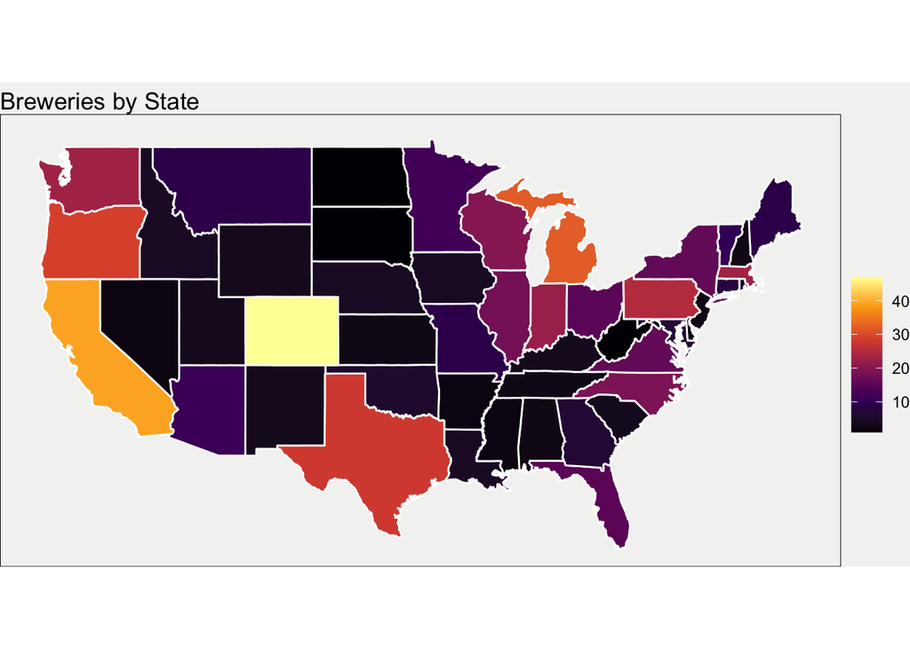

```r
# Count the breweries by state
breweries_by_st <- breweries %>%
  count(state) %>%
  rename(brewery_count = n,
         st = state) %>%
  mutate(state = tolower(state.name[match(st,state.abb)])) %>%
  filter(!is.na(state)) %>%
  select(state, brewery_count)

# Merge states map with brewery data
breweries_by_st_map <- left_join(map_data("state"), breweries_by_st, by = c("region" = "state"))

# Create the breweries by state map
ggplot(breweries_by_st_map, aes(long, lat, group = group)) +
  geom_polygon(aes(fill = brewery_count), color = "white") +
  scale_fill_viridis_c(option = "inferno") +
  labs(title = "Breweries by State",
       fill = "") +
  coord_map() +
  theme_void() +
  theme(
    panel.background = element_rect(fill = "#f3f3f2"),             #F3F3F2 is the color of the PowerPoint slide backgroud for this chart
    plot.background = element_rect(fill = "#f3f3f2", color = NA),
  )
```

```r
# Save a copy of the map to the images folder
# ggsave(here::here("images", "breweries by state.png"), dpi = "retina")

# Create a table of the number of breweries by state
# ⎼⎼⎼⎼⎼⎼⎼⎼⎼⎼⎼⎼⎼⎼⎼⎼⎼⎼⎼⎼⎼⎼⎼⎼⎼⎼⎼⎼⎼⎼⎼⎼⎼⎼⎼⎼⎼⎼⎼⎼⎼⎼⎼⎼⎼⎼⎼⎼⎼⎼⎼⎼⎼⎼⎼⎼⎼⎼⎼⎼⎼⎼⎼⎼⎼⎼⎼⎼⎼⎼⎼⎼⎼⎼⎼⎼⎼
# Because there isn't a clean way to wrap columns using the gt() function, we've
# split the data into three separate data sets then bound the columns of each
# set back together to simulate three columns of data.
by_st1 <- breweries_by_st %>%
  arrange(desc(brewery_count)) %>%
  slice(1:17)
by_st2 <- breweries_by_st %>%
  arrange(desc(brewery_count)) %>%
  slice(18:34)
by_st3 <- breweries_by_st %>%
  arrange(desc(brewery_count)) %>%
  slice(35:51) %>%
  add_row()
bind_cols(by_st1,
          by_st2,
          by_st3) %>%
  gt() %>%
  tab_header(title = "How Many Breweries are Present in Each State?") %>%
  cols_label(`state...1` = "State",
             `brewery_count...2` = "Count",
             `state...3` = "State",
             `brewery_count...4` = "Count",
             `state...5` = "State",
             `brewery_count...6` = "Count") %>%
  {.}
```

```
## * state -> state...1
## * brewery_count -> brewery_count...2
## * state -> state...3
## * brewery_count -> brewery_count...4
## * state -> state...5
## * ...
```

How Many Breweries are Present in Each State?

| State | Count | State | Count | State | Count |
| --- | --- | --- | --- | --- | --- |
| colorado | 47 | arizona | 11 | new mexico | 4 |
| california | 39 | vermont | 10 | south carolina | 4 |
| michigan | 32 | maine | 9 | utah | 4 |
| oregon | 29 | missouri | 9 | wyoming | 4 |
| texas | 28 | montana | 9 | alabama | 3 |
| pennsylvania | 25 | connecticut | 8 | kansas | 3 |
| massachusetts | 23 | alaska | 7 | new hampshire | 3 |
| washington | 23 | georgia | 7 | new jersey | 3 |
| indiana | 22 | maryland | 7 | tennessee | 3 |
| wisconsin | 20 | oklahoma | 6 | arkansas | 2 |
| north carolina | 19 | iowa | 5 | delaware | 2 |
| illinois | 18 | idaho | 5 | mississippi | 2 |
| new york | 16 | louisiana | 5 | nevada | 2 |
| virginia | 16 | nebraska | 5 | north dakota | 1 |
| florida | 15 | rhode island | 5 | south dakota | 1 |
| ohio | 15 | hawaii | 4 | west virginia | 1 |
| minnesota | 12 | kentucky | 4 | NA | NA |

```r
# Create a table of the top 10 states for breweries
breweries %>%
  count(state) %>%
  arrange(desc(n)) %>%
  slice(1:10) %>%
  gt() %>%
  tab_header(title = "Top 10 States") %>%
  cols_label(state = "State",
             n = "Breweries")
```

Top 10 States

| State | Breweries |
| --- | --- |
| CO | 47 |
| CA | 39 |
| MI | 32 |
| OR | 29 |
| TX | 28 |
| PA | 25 |
| MA | 23 |
| WA | 23 |
| IN | 22 |
| WI | 20 |

```r
# Create a table of the bottom 10 states for breweries
breweries %>%
  count(state) %>%
  arrange(n) %>%
  slice(1:10) %>%
  gt() %>%
  tab_header(title = "Bottom 10 States") %>%
  cols_label(state = "State",
             n = "Breweries")
```

Bottom 10 States

| State | Breweries |
| --- | --- |
| DC | 1 |
| ND | 1 |
| SD | 1 |
| WV | 1 |
| AR | 2 |
| DE | 2 |
| MS | 2 |
| NV | 2 |
| AL | 3 |
| KS | 3 |

The top three states are Colorado (47), California (39), and Michigan (32). The bottom three states are North Dakota (1), South Dakota (1), and West Virginia (1).

## Merge Beer & Breweries Data

After taking a look at the brewery data, we next merged it with the beer data in order to start our analysis of alcohol by volume (ABV) and international bitterness units (IBU). We’ll take a look at the data after we merged it to make sure everything looks ok.

```r
# Merge the beer and brewery data sets
beer_brew <- left_join(beers, breweries, by = c("brewery_id" = "brew_id"))

# Clean up column names post-merge
beer_brew <- beer_brew %>%
  rename(beer_name = name.x,
         brewery_name = name.y)

# Look at the first six observations
beer_brew %>%
  slice_head(n = 6) %>%
  gt() %>%
  tab_header(title = "First Six Observations")
```

First Six Observations

| beer_name | beer_id | abv | ibu | brewery_id | style | ounces | brewery_name | city | state |
| --- | --- | --- | --- | --- | --- | --- | --- | --- | --- |
| Pub Beer | 1436 | 0.050 | NA | 409 | American Pale Lager | 12 | 10 Barrel Brewing Company | Bend | OR |
| Devil's Cup | 2265 | 0.066 | NA | 178 | American Pale Ale (APA) | 12 | 18th Street Brewery | Gary | IN |
| Rise of the Phoenix | 2264 | 0.071 | NA | 178 | American IPA | 12 | 18th Street Brewery | Gary | IN |
| Sinister | 2263 | 0.090 | NA | 178 | American Double / Imperial IPA | 12 | 18th Street Brewery | Gary | IN |
| Sex and Candy | 2262 | 0.075 | NA | 178 | American IPA | 12 | 18th Street Brewery | Gary | IN |
| Black Exodus | 2261 | 0.077 | NA | 178 | Oatmeal Stout | 12 | 18th Street Brewery | Gary | IN |

```r
# Look at the last six observations
beer_brew %>%
  slice_tail(n = 6) %>%
  gt() %>%
  tab_header(title = "Last Six Observations")
```

Last Six Observations

| beer_name | beer_id | abv | ibu | brewery_id | style | ounces | brewery_name | city | state |
| --- | --- | --- | --- | --- | --- | --- | --- | --- | --- |
| Rocky Mountain Oyster Stout | 1035 | 0.075 | NA | 425 | American Stout | 12 | Wynkoop Brewing Company | Denver | CO |
| Belgorado | 928 | 0.067 | 45 | 425 | Belgian IPA | 12 | Wynkoop Brewing Company | Denver | CO |
| Rail Yard Ale | 807 | 0.052 | NA | 425 | American Amber / Red Ale | 12 | Wynkoop Brewing Company | Denver | CO |
| B3K Black Lager | 620 | 0.055 | NA | 425 | Schwarzbier | 12 | Wynkoop Brewing Company | Denver | CO |
| Silverback Pale Ale | 145 | 0.055 | 40 | 425 | American Pale Ale (APA) | 12 | Wynkoop Brewing Company | Denver | CO |
| Rail Yard Ale (2009) | 84 | 0.052 | NA | 425 | American Amber / Red Ale | 12 | Wynkoop Brewing Company | Denver | CO |

## Address Missing Values

Now that the data was successfully merged together, we began the process of investigating and addressing the missing values in the data set. Unfortunately there are a number of missing values, particularly when it comes to ABV and IBU. After examining the histograms for those two variables, we made two decisions. The first was to exclude cider and mead from the analysis because they are not beer. The second was to impute the mean ABV and IBU value by beer style for all missing values of those variables. We felt that offered the best balance between not losing observations and staying true to the beer’s style. Our final task for this question was to simply remove any remaining observations with missing values.

```r
# How many missing values do we currently have in the data?
colSums(is.na(beer_brew))
```

```
##    beer_name      beer_id          abv          ibu   brewery_id        style
##            0            0           62         1005            0            5
##       ounces brewery_name         city        state
##            0            0            0            0
```

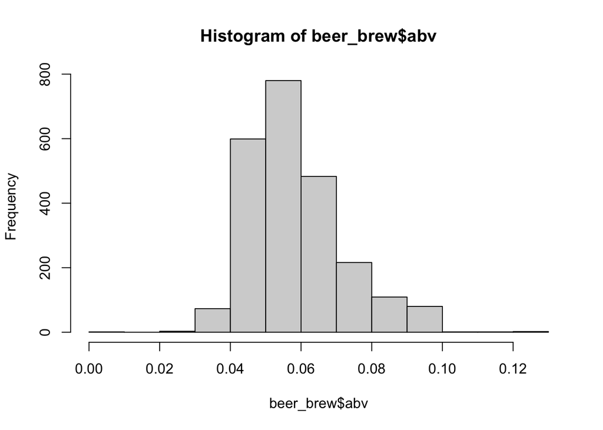

```r
# What is the distribution of ABV and IBU before imputation?
hist(beer_brew$abv)
```

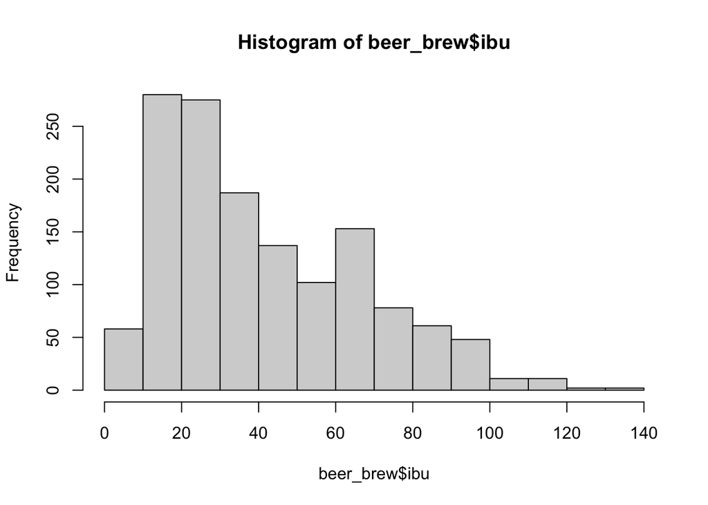

```r
hist(beer_brew$ibu)
```

```r
# Check which styles are NA for ABV and IBU
filter(beer_brew, ibu == "NaN")
```

```
## # A tibble: 0 x 10
## # … with 10 variables: beer_name <chr>, beer_id <dbl>, abv <dbl>, ibu <dbl>,
## #   brewery_id <dbl>, style <chr>, ounces <dbl>, brewery_name <chr>,
## #   city <chr>, state <chr>
```

```r
filter(beer_brew, abv == "NaN")
```

```
## # A tibble: 0 x 10
## # … with 10 variables: beer_name <chr>, beer_id <dbl>, abv <dbl>, ibu <dbl>,
## #   brewery_id <dbl>, style <chr>, ounces <dbl>, brewery_name <chr>,
## #   city <chr>, state <chr>
```

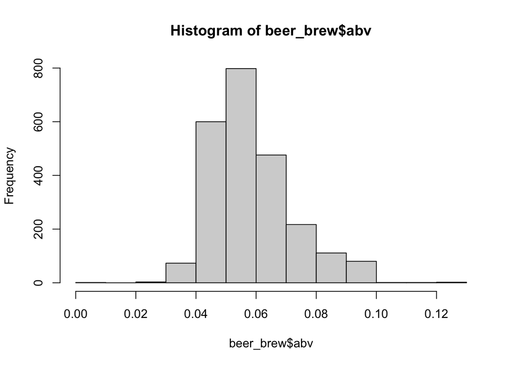

```r
# Get rid of cider and mead because they are not beer
beer_brew <- beer_brew %>%
  filter((style != "Cider") & (style != "Mead"))

# Create a function to impute the mean
impute_mean <- function(x) {
  ind_na <- is.na(x)
  x[ind_na] <- mean(x[!ind_na])
  as.numeric(x)
}

# Calculate mean IBU & ABV
beer_brew <- beer_brew %>%
  group_by(style) %>%
  mutate_at(vars(ibu, abv), impute_mean) %>%
  ungroup()

# Distribution of ABV and IBU after imputation
hist(beer_brew$abv)
```

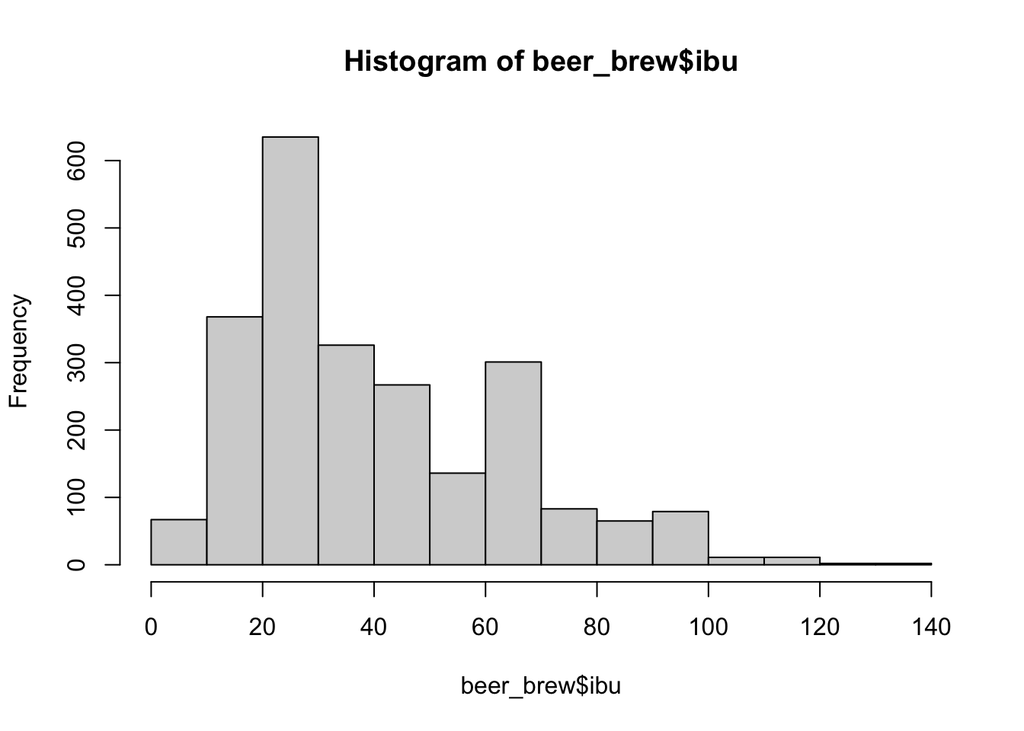

```r
hist(beer_brew$ibu)
```

```r
# Check for any remaining NA
colSums(is.na(beer_brew))
```

```
##    beer_name      beer_id          abv          ibu   brewery_id        style
##            0            0            0           10            0            0
##       ounces brewery_name         city        state
##            0            0            0            0
```

```r
# Still a stubborn 10 rows that are NA - this is because these styles don't have
# IBU. Remove these rows
beer_brew <- beer_brew %>%
  drop_na(ibu)

# Check for any remaining NA
colSums(is.na(beer_brew))
```

```
##    beer_name      beer_id          abv          ibu   brewery_id        style
##            0            0            0            0            0            0
##       ounces brewery_name         city        state
##            0            0            0            0
```

## Median ABV & IBU

Using our merged data, we created a new data set to investigate the distribution of median ABV and IBU by state. For this question we made the decision to use histograms that were arranged in descending order from largest median to the smallest.

```r
# Median ABV & IBU
median_abv_ibu <- beer_brew %>%
  filter(state != "DC") %>%
  group_by(state) %>%
  summarise(median_abv = median(abv, na.rm = TRUE),
            median_ibu = median(ibu, na.rm = TRUE)) %>%
  rename(st = state) %>%
  mutate(state = tolower(state.name[match(st,state.abb)]),
         median_abv_per = median_abv * 100) %>%
  ungroup() %>%
  pivot_longer(cols = c(3,5), names_to = "measure")
```

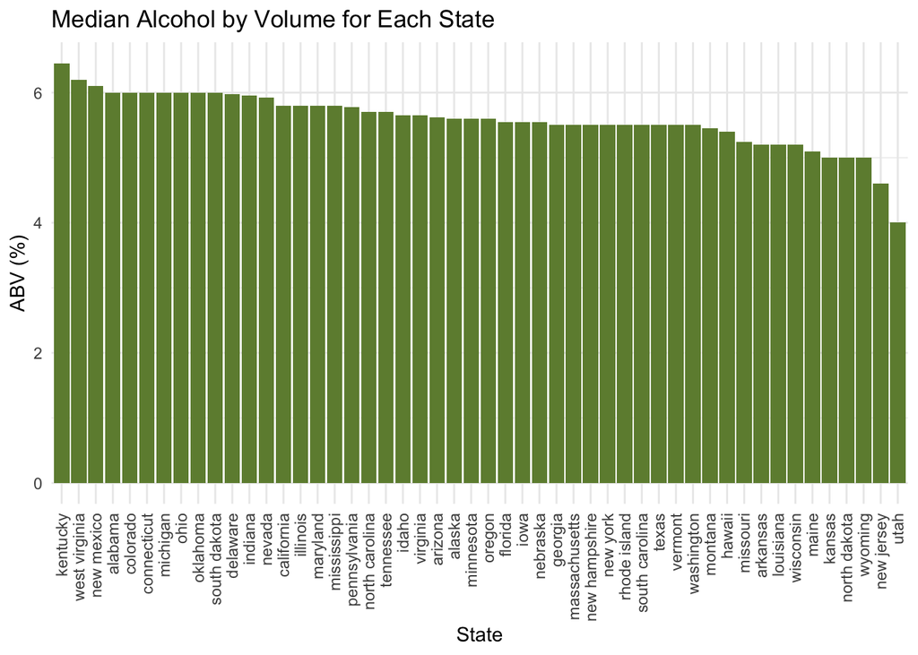

```r
# ABV Histogram
median_abv_ibu %>%
  filter(measure == "median_abv_per") %>%
  ggplot(aes(x = reorder(state, -value), y = value)) +
  geom_bar(stat = "identity", fill = "darkolivegreen4") +
  labs(title ="Median Alcohol by Volume for Each State",
       x = "State",
       y = "ABV (%)") +
  scale_x_discrete(guide = guide_axis(angle = 90))  +
  theme_minimal() +
  NULL
```

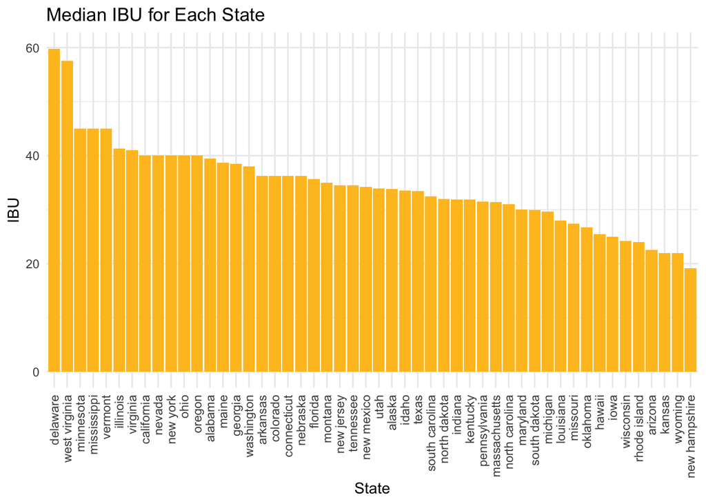

```r
# Save the ABV histogram to the images folder
# ggsave(
#   here::here("images", "median abv by state.png"),
#   dpi = "retina",
#   width = 10,
#   height = 3,
#   units = "in"
# )

# IBU Histogram
median_abv_ibu %>%
  filter(measure == "median_ibu") %>%
  ggplot(aes(x = reorder(state, -value), y = value)) +
  geom_bar(stat = "identity", fill = "goldenrod1") +
  labs(title ="Median IBU for Each State",
       x = "State",
       y = "IBU") +
  scale_x_discrete(guide = guide_axis(angle = 90))  +
  theme_minimal() +
  NULL
```

```r
# Save the ABV histogram to the images folder
# ggsave(
#   here::here("images", "median ibu by state.png"),
#   dpi = "retina",
#   width = 10,
#   height = 3,
#   units = "in"
# )
```

Delaware and West Virginia have the highest median IBU, but only include two beers per state. After that, Minnesota has the highest median IBU at 45 and includes a total of 12 breweries.

Kentucky has the highest median ABV at 6.5%.

### Mapping the Data Instead

While the histograms offer a quick look at the median distribution and an assessment of which state has the highest and lowest median values, we also thought it would be interesting to once again map the data to see if there were regional trends that might be hiding in the data.

```r
# Re-make the median_abv_ibu data set without the pivot longer and highlights
median_abv_ibu <- beer_brew %>%
  filter(state != "DC") %>%
  group_by(state) %>%
  summarise(median_abv = median(abv, na.rm = TRUE),
            median_ibu = median(ibu, na.rm = TRUE)) %>%
  rename(st = state) %>%
  mutate(state = tolower(state.name[match(st,state.abb)]),
         median_abv_per = median_abv * 100)
```

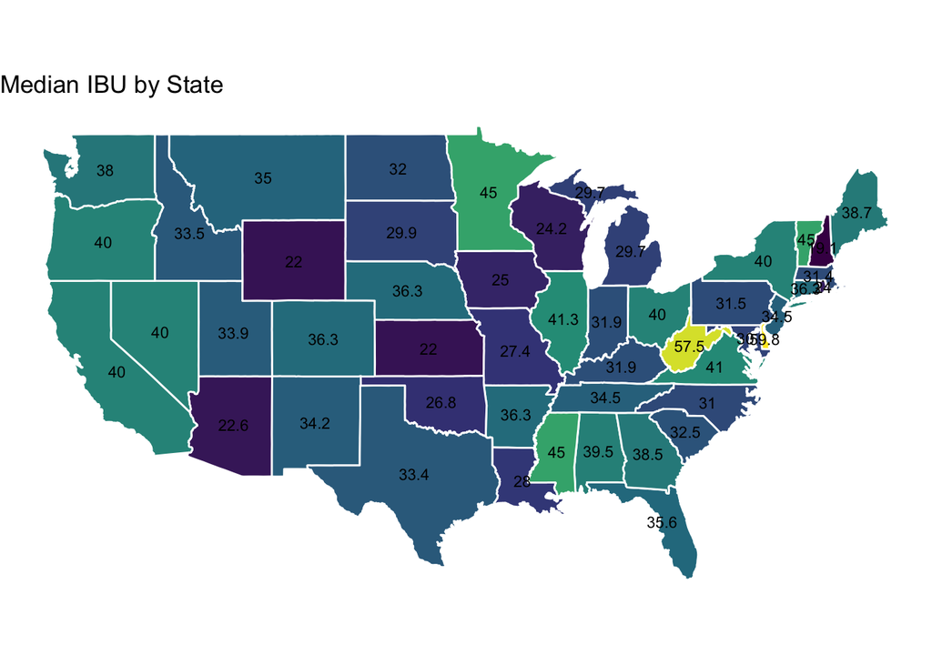

```r
# Merge the state and beer data together
median_map <- left_join(map_data("state"), median_abv_ibu, by = c("region" = "state"))

# Use the map function to get the polygon data, then find the centroids
state_poly <- maps::map("state",  plot=FALSE, fill = TRUE)

# Define state centroids to plot values on states
state_centroids <- maps:::apply.polygon(state_poly, maps:::centroid.polygon)

# Create a data frame for graphing out of the centroids of each polygon
# with a non-missing name
state_centroids <- state_centroids[!is.na(names(state_centroids))]
centroid_array <- Reduce(rbind, state_centroids)
dimnames(centroid_array) <-
  list(gsub("[^,]*,", "", names(state_centroids)),
       c("long", "lat"))
label_df <- as.data.frame(centroid_array)
label_df$state <- rownames(label_df)

# Remove extra names
label_df <- label_df[-c(20, 22, 34, 36, 37, 38, 40, 53, 54, 56, 57, 58, 59), ]

# Remove subregion
label_df$state <- str_extract(label_df$state, "[a-z ]+")

# Join label data with median_abv_ibu value
median_map_label <- left_join(label_df, median_abv_ibu, by = c("state" = "state"))

# Create a map of median IBU by state with value
ggplot(median_map, aes(long, lat, group = group)) +
  geom_polygon(aes(fill = median_ibu), color = "white") +
  geom_text(data = median_map_label,
            aes(label = round(median_ibu, digits = 1), group = state),
            size = 3) +
  scale_fill_viridis_c() +
  labs(title = "Median IBU by State",
       fill = "Median IBU") +
  guides(fill = FALSE) +
  coord_map() +
  theme_void()
```

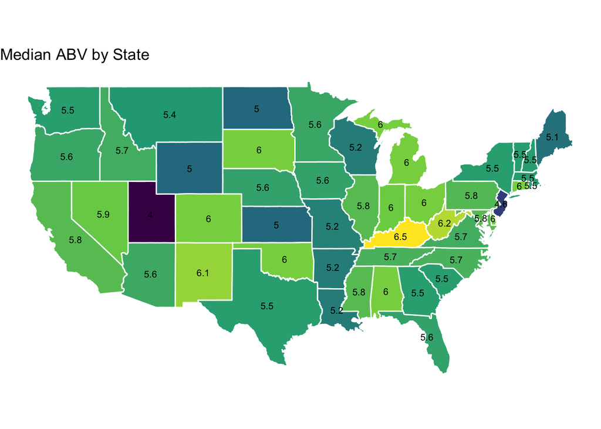

```r
# Save the map to the images folder
# ggsave(here::here("images", "median ibu by state map.png"), dpi = "retina")

# Create a map of median ABV by state with value
ggplot(median_map, aes(long, lat, group = group)) +
  geom_polygon(aes(fill = median_abv), color = "white") +
  geom_text(data = median_map_label,
            aes(label = round(median_abv_per, digits = 1), group =
                  state),
            size = 2.75) +
  scale_fill_viridis_c() +
  labs(title = "Median ABV by State",
       fill = "Median ABV (%)") +
  guides(fill = FALSE) +
  coord_map() +
  theme_void()
```

```r
# Save the map to the images folder
# ggsave(here::here("images", "median abv by state map.png"), dpi = "retina")

#which are the high IBU beers in DE, WV
beer_brew %>%
  filter(state == "DE" | state == "WV")
```

```
## # A tibble: 4 x 10
##   beer_name beer_id    abv   ibu brewery_id style ounces brewery_name city
##   <chr>       <dbl>  <dbl> <dbl>      <dbl> <chr>  <dbl> <chr>        <chr>
## 1 Wild Tra…    2314 0.057   44          157 Amer…     12 Greenbrier … Lewi…
## 2 Mothman …    2313 0.067   71          157 Amer…     12 Greenbrier … Lewi…
## 3 Apprecia…    1784 0.0645  67.6        317 Amer…     16 Iron Hill B… Wilm…
## 4 Greenvil…     433 0.055   52          540 Amer…     12 Twin Lakes … Gree…
## # … with 1 more variable: state <chr>
```

```r
#which are the low & high ABV beers in UT, WV
beer_brew %>%
  filter(state == "UT" | state == "WV")
```

```
## # A tibble: 28 x 10
##    beer_name beer_id   abv   ibu brewery_id style ounces brewery_name city
##    <chr>       <dbl> <dbl> <dbl>      <dbl> <chr>  <dbl> <chr>        <chr>
##  1 Bohemian…    1607 0.06   23.8        365 Dort…     12 Bohemian Br… Midv…
##  2 Altus Bo…    1597 0.053  34.1        365 Altb…     12 Bohemian Br… Midv…
##  3 Cherny B…     344 0.04   31          365 Schw…     12 Bohemian Br… Midv…
##  4 Czech Pi…      89 0.05   33.8        365 Czec…     12 Bohemian Br… Midv…
##  5 Viennese…      88 0.05   24.4        365 Vien…     12 Bohemian Br… Midv…
##  6 Wild Tra…    2314 0.057  44          157 Amer…     12 Greenbrier … Lewi…
##  7 Mothman …    2313 0.067  71          157 Amer…     12 Greenbrier … Lewi…
##  8 Squeaky …    1476 0.04   29.9        400 Amer…     16 Moab Brewery Moab
##  9 Dead Hor…     902 0.04   20.7        400 Amer…     16 Moab Brewery Moab
## 10 Rocket B…     645 0.04   41          400 Cali…     16 Moab Brewery Moab
## # … with 18 more rows, and 1 more variable: state <chr>
```

## Max ABV & IBU

To determine which beer had the highest ABV and IBU, respectively, we arranged the data set in descending order by the desired variable and kept only the top record. The state with the highest ABV was Colorado and the state with the highest IBU was Oregon.

```r
# Highest ABV
beer_brew %>%
  arrange(desc(abv)) %>%
  filter(row_number() == 1)
```

```
## # A tibble: 1 x 10
##   beer_name beer_id   abv   ibu brewery_id style ounces brewery_name city  state
##   <chr>       <dbl> <dbl> <dbl>      <dbl> <chr>  <dbl> <chr>        <chr> <chr>
## 1 Lee Hill…    2565 0.128    24         52 Quad…   19.2 Upslope Bre… Boul… CO
```

```r
# Highest IBU
beer_brew %>%
  arrange(desc(ibu)) %>%
  filter(row_number() == 1)
```

```
## # A tibble: 1 x 10
##   beer_name beer_id   abv   ibu brewery_id style ounces brewery_name city  state
##   <chr>       <dbl> <dbl> <dbl>      <dbl> <chr>  <dbl> <chr>        <chr> <chr>
## 1 Bitter B…     980 0.082   138        375 Amer…     12 Astoria Bre… Asto… OR
```

## ABV Summary Stats and Distribution

Comment on the summary statistics and distribution of the ABV variable.

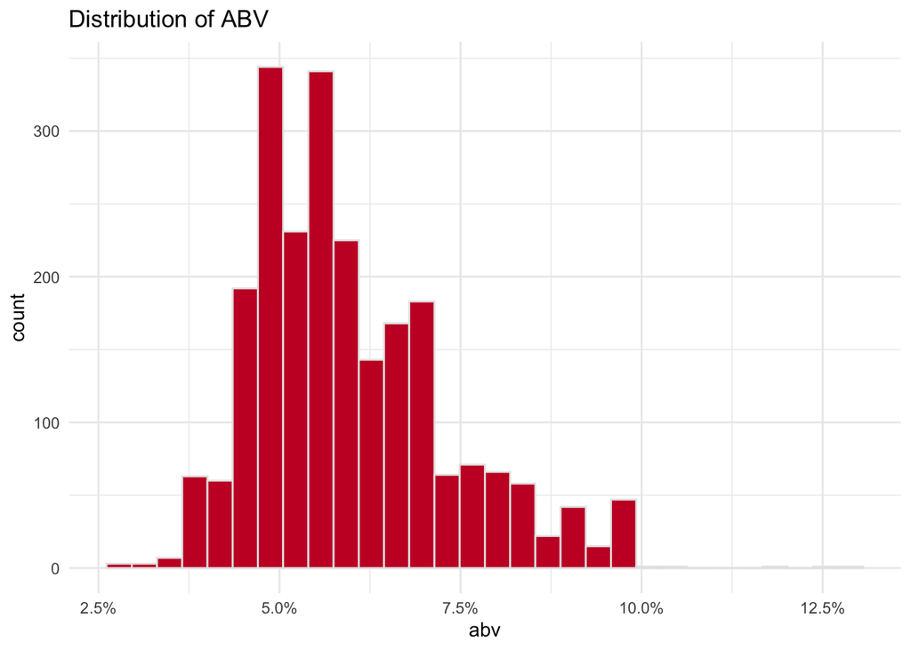

```r
# Histogram of ABV
beer_brew %>%
  ggplot(aes(x = abv)) +
  geom_histogram(fill = bud_red, color = "gray90") +
  scale_x_continuous(label = percent) +
  ggtitle("Distribution of ABV") +
  theme_minimal()
```

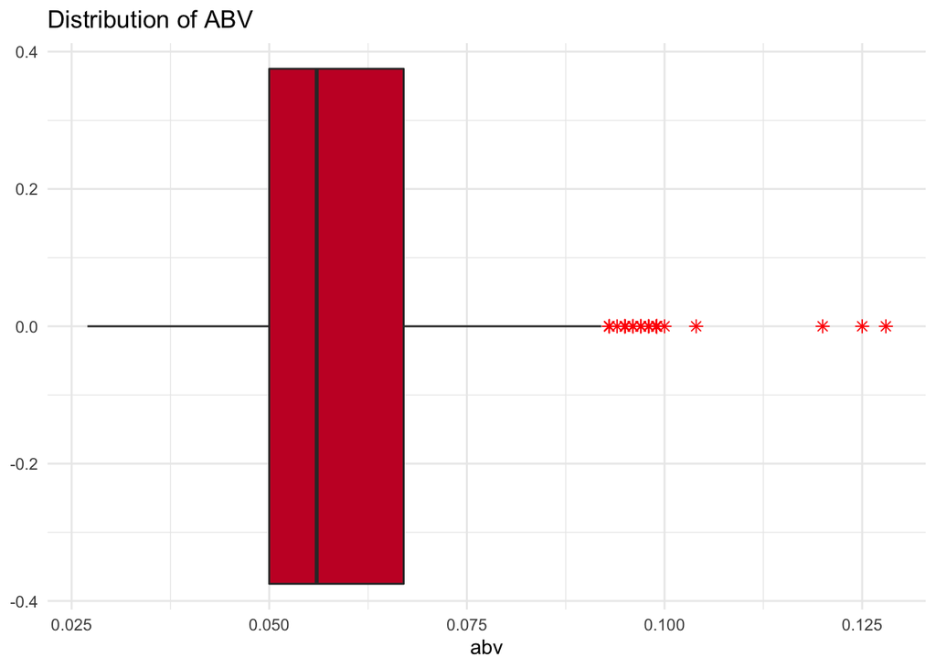

```r
# Boxplot of ABV
beer_brew %>%
  ggplot(aes(x = abv)) +
  geom_boxplot(
    outlier.colour = "red",
    outlier.shape = 8,
    outlier.size = 2,
    fill = bud_red
  ) +
  ggtitle("Distribution of ABV") +
  theme_minimal()
```

## Is there a relationship between IBU and ABV?

Is there an apparent relationship between the bitterness of the beer and its alcoholic content? Draw a scatter plot. Make your best judgment of a relationship and EXPLAIN your answer.

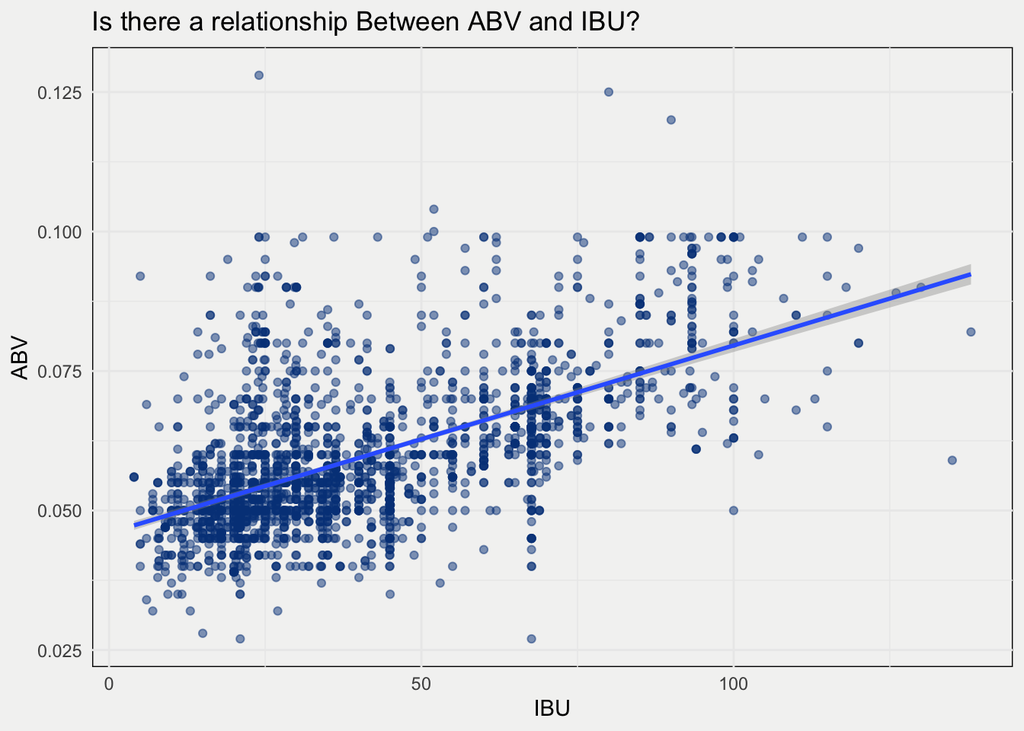

```r
# Create a scatter plot of ABV and IBU
beer_brew %>%
  ggplot(aes(x = ibu, y = abv)) +
  geom_jitter(alpha = 0.5, color = "#044389") +
  geom_smooth(method = "lm") +
  labs(title = "Is there a relationship Between ABV and IBU?",
       x = "IBU",
       y = "ABV") +
  theme_minimal() +
  theme(
    panel.background = element_rect(fill = "#f3f3f2"),
    plot.background = element_rect(fill = "#f3f3f2", color = NA),
  )
```

```r
# Save the plot to the images folder
# ggsave(here::here("images", "abv and ibu relationship.png"), dpi = "retina")
```

There does appear to be some quantifiable relationship between IBU and ABV. In general, as IBU increases, ABV appears to increase as well.

## KNN

Budweiser would also like to investigate the difference with respect to IBU and ABV between IPAs (India Pale Ales) and other types of Ale (any beer with “Ale” in its name other than IPA). You decide to use KNN classification to investigate this relationship. Provide statistical evidence one way or the other. You can of course assume your audience is comfortable with percentages…KNN is very easy to understand conceptually.

In addition, while you have decided to use KNN to investigate this relationship (KNN is required) you may also feel free to supplement your response to this question with any other methods or techniques you have learned. Creativity and alternative solutions are always encouraged.

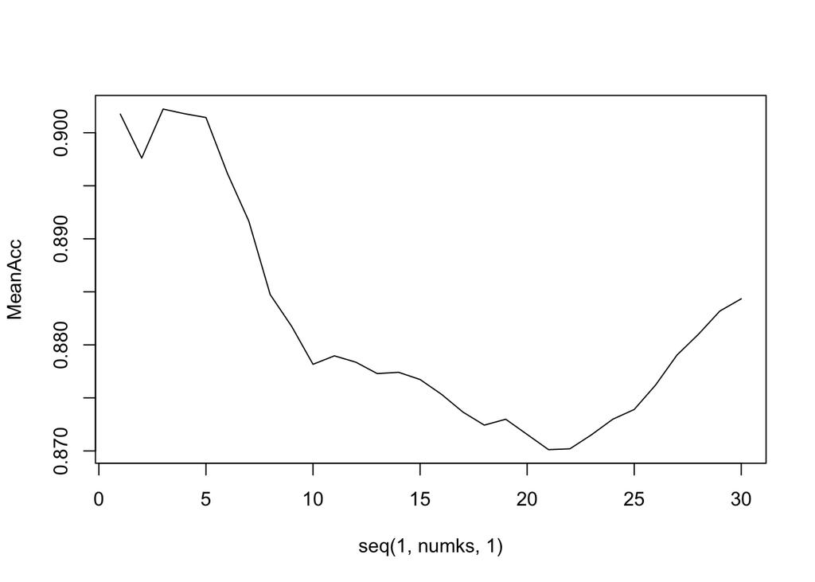

```r
# Create data set of beers whose style contains only "IPA" or "Ale"
ipa_ale <- beer_brew %>%
  mutate(style2 = as_factor(case_when(str_detect(style, "IPA") ~ "IPA",
                                      str_detect(style, "ale") ~ "Ale"))) %>%
  filter(!is.na(style2)) %>%
  select(style2,
         abv,
         ibu)

# Create a new standardized data set for knn
ipa_ale$abv_std <- standardize(ipa_ale$abv, centerFun = mean, scaleFun = sd)
ipa_ale$ibu_std <- standardize(ipa_ale$ibu, centerFun = mean, scaleFun = sd)

# Set seed
set.seed(123)

# Find the optimum k for predicting beer type based on IBU and ABV
# ⎼⎼⎼⎼⎼⎼⎼⎼⎼⎼⎼⎼⎼⎼⎼⎼⎼⎼⎼⎼⎼⎼⎼⎼⎼⎼⎼⎼⎼⎼⎼⎼⎼⎼⎼⎼⎼⎼⎼⎼⎼⎼⎼⎼⎼⎼⎼⎼⎼⎼⎼⎼⎼⎼⎼⎼⎼⎼⎼⎼⎼⎼⎼⎼⎼⎼⎼⎼⎼⎼⎼⎼⎼⎼⎼⎼⎼
# Set the number of iterations
iterations <- 100

# Set the number of K's to test
numks <- 30

# Create a blank matrix for holding for loop results
masterAcc <- matrix(nrow = iterations, ncol = numks)

# For loop to split the data into training and testing sets, run a KNN on each
# value of K, create a confusion matrix and add the results to our previously
# created blank matrix
for (j in 1:iterations) {
  trainInd <- sample(1:dim(ipa_ale)[1], round(0.75 * dim(ipa_ale)[1]))
  train <- ipa_ale[trainInd, ]
  test <- ipa_ale[-trainInd, ]

  for (i in 1:numks)
  {
    classifications <-
      knn(
        train[, c(2, 3)],
        test[, c(2, 3)],
        train$style2,
        prob = TRUE,
        k = i,
        use.all = TRUE
      )
    CM <- confusionMatrix(table(classifications, test$style2))
    masterAcc[j, i] <- CM$overall[1]
  }
}

# Calculate the column means
MeanAcc <- colMeans(masterAcc)

# Plot results
plot(seq(1, numks, 1), MeanAcc, type = "l")
```

```r
# Which K was most successful.
which.max(MeanAcc)
```

```
## [1] 3
```

Based on this look for 30 different k’s, we see the optimum accuracy is at k = 3.

```r
# Run the KNN model with our optimum k
trainInd <- sample(1:dim(ipa_ale)[1], round(0.75 * dim(ipa_ale)[1]))
train <- ipa_ale[trainInd,]
test <- ipa_ale[-trainInd,]
knn_model <- knn(train[, c(2, 3)], test[, c(2, 3)], train$style2, k = 3)
CM <- confusionMatrix(knn_model, test$style2)
CM
```

```
## Confusion Matrix and Statistics
##
##           Reference
## Prediction Ale IPA
##        Ale 107  18
##        IPA   9 117
##
##                Accuracy : 0.8924
##                  95% CI : (0.8474, 0.9279)
##     No Information Rate : 0.5378
##     P-Value [Acc > NIR] : <2e-16
##
##                   Kappa : 0.7848
##
##  Mcnemar's Test P-Value : 0.1237
##
##             Sensitivity : 0.9224
##             Specificity : 0.8667
##          Pos Pred Value : 0.8560
##          Neg Pred Value : 0.9286
##              Prevalence : 0.4622
##          Detection Rate : 0.4263
##    Detection Prevalence : 0.4980
##       Balanced Accuracy : 0.8945
##
##        'Positive' Class : Ale
##
```

## Knock Their Socks Off

As we explored IBU, we noticed that the higher median IBU values tended to fall around the coasts and major metropolitan areas. That got us thinking about the relative dearth of hoppy, higher-IBU beer across much of the middle of the country and the opportunity that presents you with at Budweiser. Your brand power, trusted reputation for quality, and your distribution pipeline have placed you in an ideal position to beginn capitalizing on the popularity that higher IBU beers have begun to enjoy.

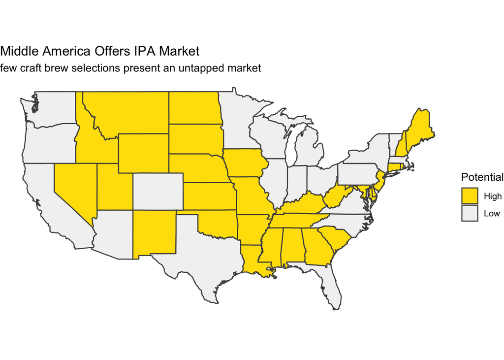

```r
explore <- beer_brew %>%
  mutate(style2 = as_factor(case_when(str_detect(style, "IPA") ~ "IPA",
                                      str_detect(style, "ale") ~ "Ale"))) %>%
  filter(style2 == "IPA") %>%
  count(state) %>%
  rename(st = state,
         ipas = n) %>%
  mutate(region = tolower(state.name[match(st,state.abb)]))

explore <- left_join(map_data("state"), explore)
explore$ipas[is.na(explore$ipas)] <- 0

explore %>%
  mutate(ipa_potential = if_else(ipas < 10, "High", "Low")) %>%
  ggplot(aes(long, lat, group = group)) +
  geom_polygon(aes(fill = ipa_potential), color = "gray30") +
  scale_fill_manual(values = c("#ffdf00", alpha("gray90", 0.5))) +
  labs(title = "Middle America Offers IPA Market",
       subtitle = "few craft brew selections present an untapped market",
       fill = "Potential") +
  coord_map() +
  theme_void() #+
```

```r
  theme(
  panel.background = element_rect(fill = "#f3f3f2"),
    # bg of the panel
    plot.background = element_rect(fill = "#f3f3f2", color = NA),
    # bg of the plot
    legend.position = "bottom")
```

[output not shown]

```r
# ggsave(here::here("images", "ipa potential.png"), dpi = "retina")
```

## Additional Exploration

The following are additional explorations that we considered for the questions in this analysis. We opted to include it to show our thought process as well as provide ideas for future exploration.

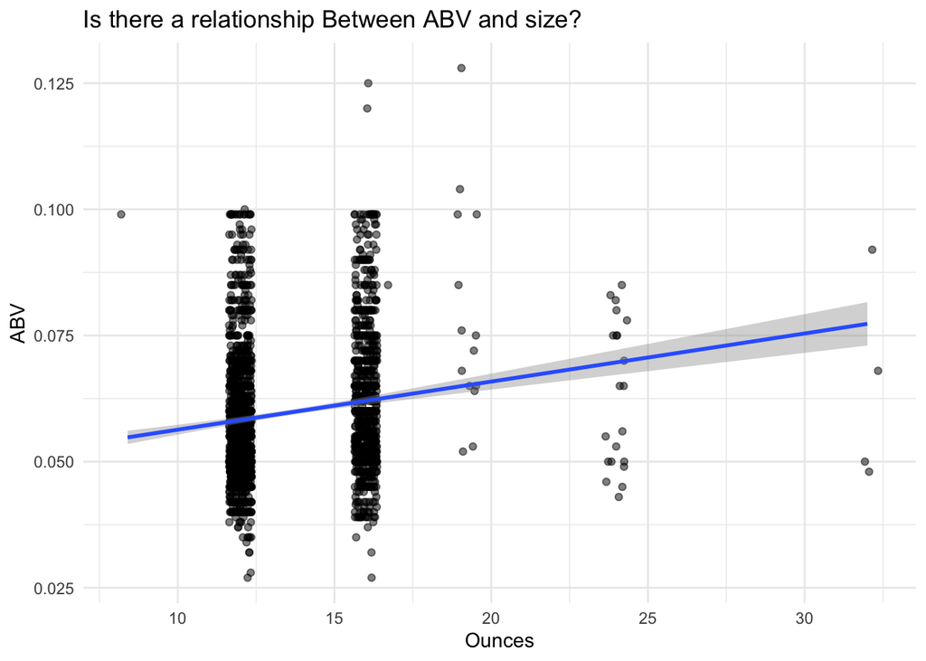

```r
# Additional EDA with size and ABV
beer_brew %>%
  ggplot(aes(x = ounces, y = abv)) +
  geom_jitter(alpha = 0.5) +
  geom_smooth(method = "lm") +
  labs(
    title = "Is there a relationship Between ABV and size?",
    x = "Ounces",
    y = "ABV"
  ) +
  theme_minimal()
```

```r
# All of the beer styles
beer_brew$style <- as.factor(beer_brew$style)

# Most popular styles
beer_brew %>%
  count(style) %>%
  rename(style_count = n) %>%
  arrange(desc(style_count))
```

```
## # A tibble: 90 x 2
##    style                          style_count
##    <fct>                                <int>
##  1 American IPA                           424
##  2 American Pale Ale (APA)                245
##  3 American Amber / Red Ale               133
##  4 American Blonde Ale                    108
##  5 American Double / Imperial IPA         105
##  6 American Pale Wheat Ale                 97
##  7 American Brown Ale                      70
##  8 American Porter                         68
##  9 Saison / Farmhouse Ale                  52
## 10 Witbier                                 51
## # … with 80 more rows
```

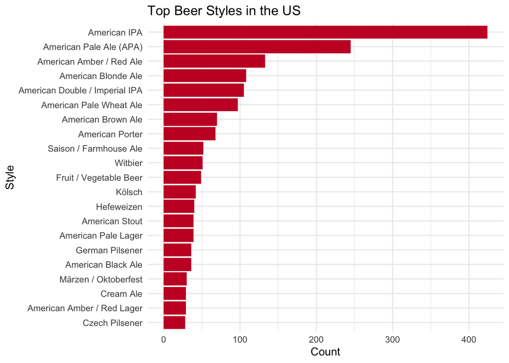

```r
# Plot bar graph of styles - adapted from Kaggle code
beer_brew %>%
  group_by(style) %>% # Group by the beer style
  summarise(count = n()) %>% # Count per group
  filter(count > 25) %>% # Only the larger groups
  ggplot(aes(reorder(style, count), count)) + # Reorder the bars
  geom_col(fill = '#C8102E') +
  labs(
    title = "Top Beer Styles in the US",
    x = "Style",
    y = "Count"
  ) +
  theme_minimal() +
  coord_flip()
```

```r
# What are the beers in Utah?
beer_brew %>%
  filter(state == "UT")
```

```
## # A tibble: 26 x 10
##    beer_name beer_id   abv   ibu brewery_id style ounces brewery_name city
##    <chr>       <dbl> <dbl> <dbl>      <dbl> <fct>  <dbl> <chr>        <chr>
##  1 Bohemian…    1607 0.06   23.8        365 Dort…     12 Bohemian Br… Midv…
##  2 Altus Bo…    1597 0.053  34.1        365 Altb…     12 Bohemian Br… Midv…
##  3 Cherny B…     344 0.04   31          365 Schw…     12 Bohemian Br… Midv…
##  4 Czech Pi…      89 0.05   33.8        365 Czec…     12 Bohemian Br… Midv…
##  5 Viennese…      88 0.05   24.4        365 Vien…     12 Bohemian Br… Midv…
##  6 Squeaky …    1476 0.04   29.9        400 Amer…     16 Moab Brewery Moab
##  7 Dead Hor…     902 0.04   20.7        400 Amer…     16 Moab Brewery Moab
##  8 Rocket B…     645 0.04   41          400 Cali…     16 Moab Brewery Moab
##  9 Johnny's…     644 0.04   67.6        400 Amer…     16 Moab Brewery Moab
## 10 PUNK'N       2310 0.05   10          160 Pump…     12 Uinta Brewi… Salt…
## # … with 16 more rows, and 1 more variable: state <chr>
```

```r
# 26 total beers, three cities: Midvale, Moab, SLC

# What are the beer styles in Utah?
beer_brew %>%
  filter(state == "UT") %>%
  count(style) %>%
  rename(style_count = n) %>%
  arrange(desc(style_count)) %>%
  gt() %>%
  tab_header(title = "Beer Styles in Utah")
```

Beer Styles in Utah

| style | style_count |
| --- | --- |
| American IPA | 4 |
| American Pale Ale (APA) | 4 |
| American Double / Imperial IPA | 2 |
| American White IPA | 2 |
| Schwarzbier | 2 |
| Altbier | 1 |
| American Amber / Red Lager | 1 |
| American Blonde Ale | 1 |
| American Brown Ale | 1 |
| American Pale Wheat Ale | 1 |
| California Common / Steam Beer | 1 |
| Czech Pilsener | 1 |
| Doppelbock | 1 |
| Dortmunder / Export Lager | 1 |
| Fruit / Vegetable Beer | 1 |
| Pumpkin Ale | 1 |
| Vienna Lager | 1 |

```r
# What are the beers in the states with only one brewery (ND, SD, WV)
beer_brew %>%
  filter(state == "ND" | state == "SD" | state == "WV")
```

```
## # A tibble: 12 x 10
##    beer_name beer_id   abv   ibu brewery_id style ounces brewery_name city
##    <chr>       <dbl> <dbl> <dbl>      <dbl> <fct>  <dbl> <chr>        <chr>
##  1 Red Wate…    2145 0.065  36.3        213 Amer…     12 Crow Peak B… Spea…
##  2 Mjöllnir     1804 0.066  22.2        213 Herb…     12 Crow Peak B… Spea…
##  3 Bear But…    1602 0.055  29.9        213 Amer…     12 Crow Peak B… Spea…
##  4 Easy Liv…    1301 0.045  21.0        213 Amer…     12 Crow Peak B… Spea…
##  5 Canyon C…     542 0.055  20.3        213 Crea…     12 Crow Peak B… Spea…
##  6 Pile O'D…     272 0.069  31.9        213 Amer…     12 Crow Peak B… Spea…
##  7 11th Hou…     271 0.06   67.6        213 Amer…     12 Crow Peak B… Spea…
##  8 Iron Hor…    1722 0.05   32          336 Amer…     12 Fargo Brewi… Fargo
##  9 Stone's …    1435 0.045  19          336 Scot…     12 Fargo Brewi… Fargo
## 10 Wood Chi…    1434 0.067  70          336 Amer…     12 Fargo Brewi… Fargo
## 11 Wild Tra…    2314 0.057  44          157 Amer…     12 Greenbrier … Lewi…
## 12 Mothman …    2313 0.067  71          157 Amer…     12 Greenbrier … Lewi…
## # … with 1 more variable: state <chr>
```

```r
# Average ABV by style
beer_brew %>%
  group_by(style) %>%
  summarize(
    mean_abv = mean(abv) * 100,
    count = n()
  )
```

```
## # A tibble: 90 x 3
##    style                      mean_abv count
##    <fct>                         <dbl> <int>
##  1 Abbey Single Ale               4.9      2
##  2 Altbier                        5.44    13
##  3 American Adjunct Lager         4.87    18
##  4 American Amber / Red Ale       5.75   133
##  5 American Amber / Red Lager     4.95    29
##  6 American Barleywine            9.9      3
##  7 American Black Ale             6.90    36
##  8 American Blonde Ale            4.96   108
##  9 American Brown Ale             5.79    70
## 10 American Dark Wheat Ale        5.23     7
## # … with 80 more rows
```

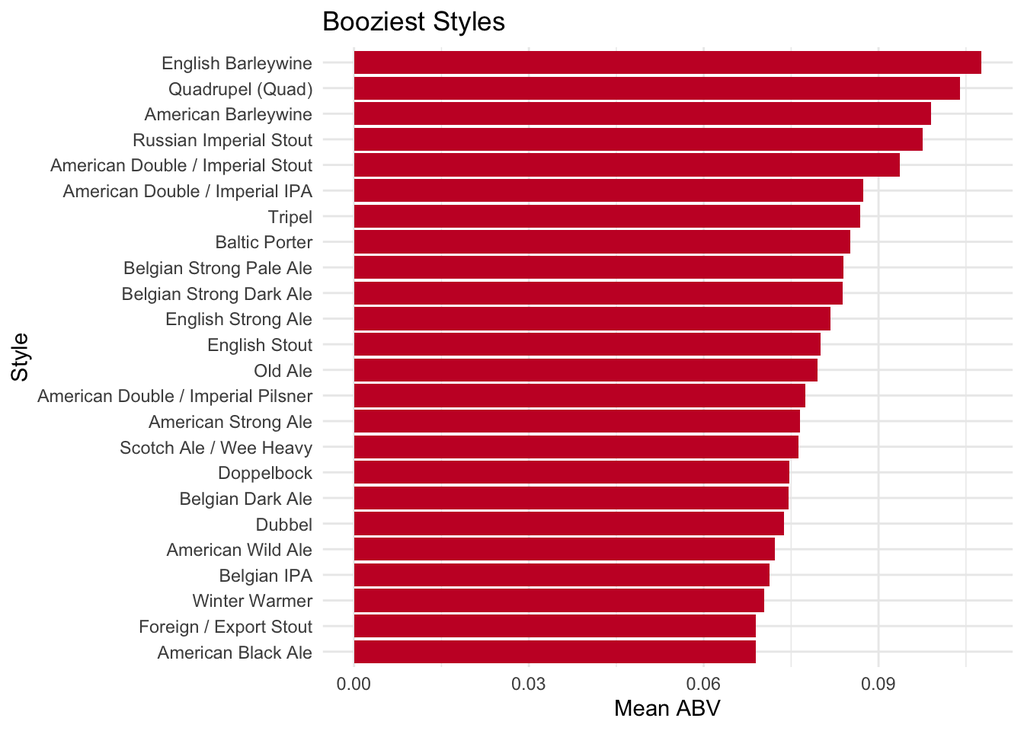

```r
# Highest ABV beer styles
beer_brew %>%
  group_by(style) %>% # Group by the beer style
  summarise(ABV = mean(abv)) %>% # mean abv by style
  filter(ABV > 0.068) %>% # Only the larger groups
  ggplot(aes(reorder(style, ABV), ABV)) + # Reorder the bars
  geom_col(fill = '#C8102E') +
  labs(
    title = "Booziest Styles",
    x = "Style",
    y = "Mean ABV"
  ) +
  theme_minimal() +
  coord_flip()
```

```r
# Average IBU by style
beer_brew %>%
  group_by(style) %>%
  summarize(
    mean_ibu = mean(ibu),
    count = n()
  )
```

```
## # A tibble: 90 x 3
##    style                      mean_ibu count
##    <fct>                         <dbl> <int>
##  1 Abbey Single Ale               22       2
##  2 Altbier                        34.1    13
##  3 American Adjunct Lager         11      18
##  4 American Amber / Red Ale       36.3   133
##  5 American Amber / Red Lager     23.2    29
##  6 American Barleywine            96       3
##  7 American Black Ale             68.9    36
##  8 American Blonde Ale            21.0   108
##  9 American Brown Ale             29.9    70
## 10 American Dark Wheat Ale        27.6     7
## # … with 80 more rows
```

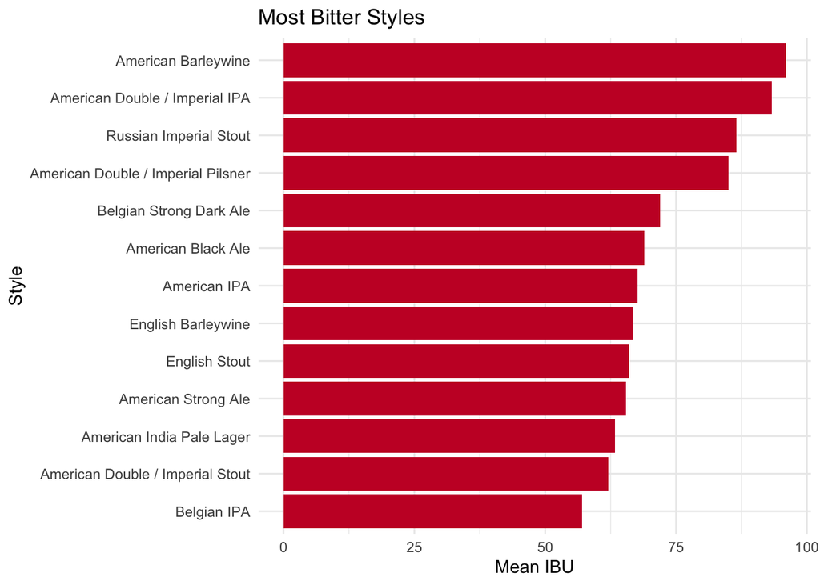

```r
# Highest IBU beer styles
beer_brew %>%
  group_by(style) %>% # Group by the beer style
  summarise(IBU = mean(ibu)) %>% # mean abv by style
  filter(IBU > 55) %>% # Only the larger groups
  ggplot(aes(reorder(style, IBU), IBU)) + # Reorder the bars
  geom_col(fill = '#C8102E') +
  labs(
    title = "Most Bitter Styles",
    x = "Style",
    y = "Mean IBU"
  ) +
  theme_minimal() +
  coord_flip()
```

```r
# American Barleywine is most bitter but also very high in ABU

# Which states have the fewest/smallest variety of styles
beer_brew %>%
  group_by(state, style) %>%
  summarize(count = n()) %>%
  ungroup()
```

```
## # A tibble: 967 x 3
##    state style                    count
##    <chr> <fct>                    <int>
##  1 AK    Altbier                      1
##  2 AK    American Amber / Red Ale     2
##  3 AK    American Blonde Ale          3
##  4 AK    American Brown Ale           1
##  5 AK    American IPA                 7
##  6 AK    American Pale Ale (APA)      2
##  7 AK    Cream Ale                    1
##  8 AK    Czech Pilsener               1
##  9 AK    English Pale Ale             1
## 10 AK    Hefeweizen                   1
## # … with 957 more rows
```

```r
#Least common styles
beer_brew %>%
  count(style) %>%
  rename(style_count = n) %>%
  arrange(style_count) %>%
  slice_head(n = 15) %>%
  gt() %>%
  tab_header(title = "Least Popular Styles") %>%
  cols_label(style = "Style",
             style_count = "Count")
```

Least Popular Styles

| Style | Count |
| --- | --- |
| Flanders Oud Bruin | 1 |
| Grisette | 1 |
| Other | 1 |
| Smoked Beer | 1 |
| Wheat Ale | 1 |
| Abbey Single Ale | 2 |
| American Double / Imperial Pilsner | 2 |
| English Stout | 2 |
| Euro Pale Lager | 2 |
| Old Ale | 2 |
| Roggenbier | 2 |
| American Barleywine | 3 |
| American India Pale Lager | 3 |
| Chile Beer | 3 |
| English Barleywine | 3 |

## Conclusion

We were able to find some interesting insights in the data based on location, IBU, and ABV. States on the coast and with major metropolitan areas tend to have more breweries and more beer variety. Utah is a state that could benefit from more variety for low alcohol content beers in particular, and Colorado is likely an already saturated market. For most of Middle America, there is an opportunity to increase distribution or even add new breweries to allow for more variety for consumers. We also suggested 15 different styles that have the least number of existing available beers that could be considered for new beers at Budweiser.